# Model Building 5 — Non-Linear Models (RF • LightGBM • XGBoost • CatBoost)

# 6. Global interpretability of the winner (LightGBM)

```python
print(f"Interpreting: {winner_name}")
```

```
Interpreting: LightGBM
```

## 6.1 Permutation importance (model-agnostic, test set)

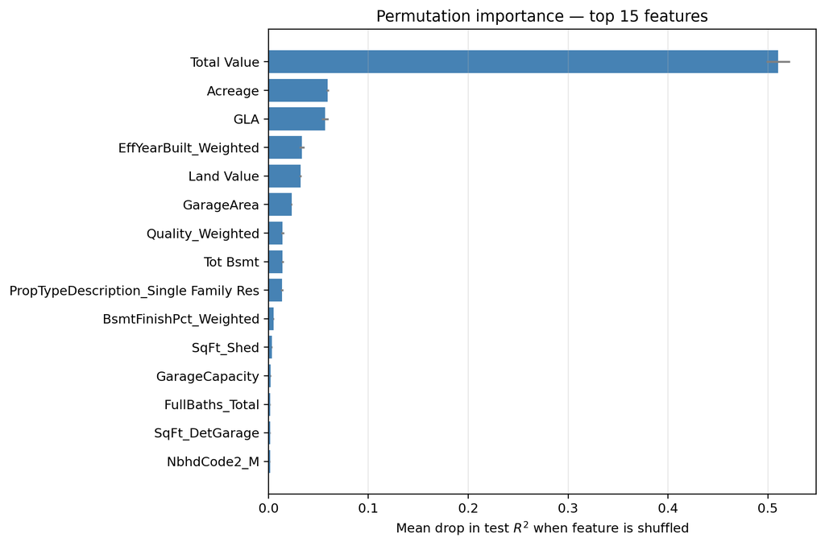

```python
perm = permutation_importance(winner, X_test, y_test,
                              n_repeats=5, random_state=RS, n_jobs=-1)
perm_df = (pd.DataFrame({'feature': X_test.columns,
                         'orig'   : [ORIG_OF[c] for c in X_test.columns],
                         'mean'   : perm.importances_mean,
                         'std'    : perm.importances_std})
             .sort_values('mean', ascending=False).head(15))

fig, ax = plt.subplots(figsize=(9, 6))
ax.barh(perm_df['orig'][::-1], perm_df['mean'][::-1],
        xerr=perm_df['std'][::-1], color='steelblue', ecolor='grey')
ax.set_xlabel('Mean drop in test $R^2$ when feature is shuffled')
ax.set_title('Permutation importance — top 15 features')
ax.grid(axis='x', alpha=0.3)
plt.tight_layout(); plt.show()
```

Permutation importance is the most honest global summary for a tree model: *how much does test $R^2$ degrade if I randomly shuffle column $j$?* It is model-agnostic and comparable across families.

## 6.2 SHAP beeswarm — global value *and* direction

```python
expl = shap.TreeExplainer(winner)
sv_test = expl.shap_values(X_test)
base_val = (float(expl.expected_value)
            if np.isscalar(expl.expected_value)
            else float(expl.expected_value[0]))
print(f"SHAP matrix: {sv_test.shape}   "
      f"base value (E[ln price]) = {base_val:.4f}  ≈ ${np.exp(base_val):,.0f}")
```

```
SHAP matrix: (2195, 79)   base value (E[ln price]) = 12.8728  ≈ $389,578
```

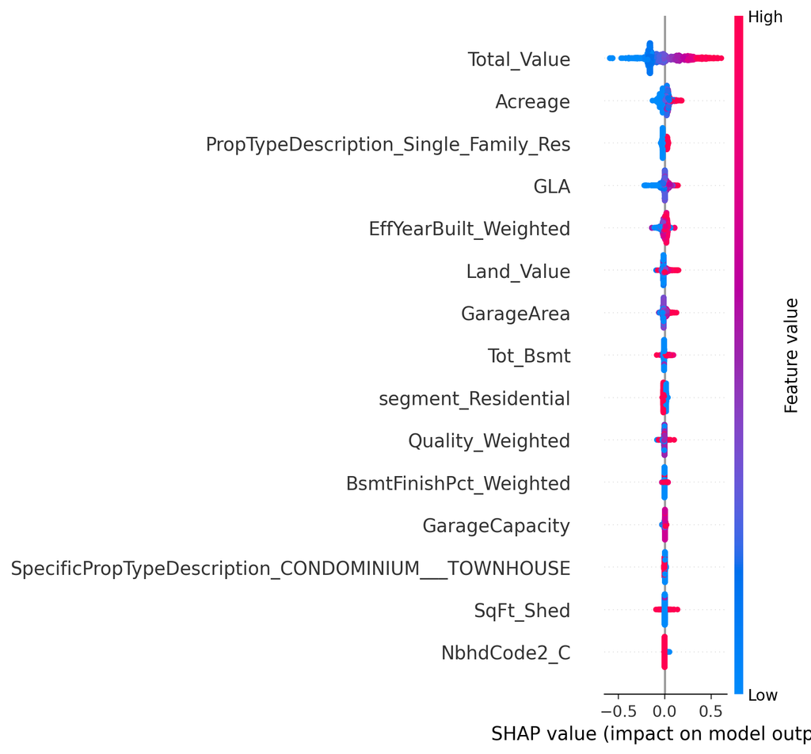

```python
shap.summary_plot(sv_test, X_test, max_display=15, show=False)
plt.tight_layout(); plt.show()
```

Each row is a feature; each dot is one test row’s SHAP value for that feature; horizontal position is the contribution to **log-price** (exponentiated, a multiplicative premium / discount); colour is the feature value (red = high, blue = low).

## 6.3 Dependence plots — how the model bends each feature

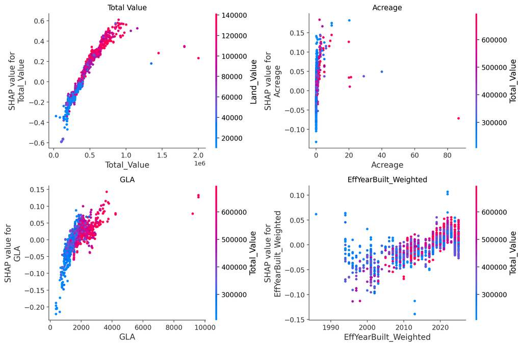

```python
top4 = perm_df['feature'].head(4).tolist()
fig, axes = plt.subplots(2, 2, figsize=(12, 8))
for ax, feat in zip(axes.ravel(), top4):
    plt.sca(ax)
    shap.dependence_plot(feat, sv_test, X_test, show=False, ax=ax)
    ax.set_title(ORIG_OF[feat])
plt.tight_layout(); plt.show()
```

Each panel shows the model’s learned effect of feature $j$ on log-price, *holding all other features at their observed values*. The y-axis is the SHAP value; the colour is the strongest interaction partner SHAP auto-detected.

## 6.4 Partial-dependence plots (marginal effects)

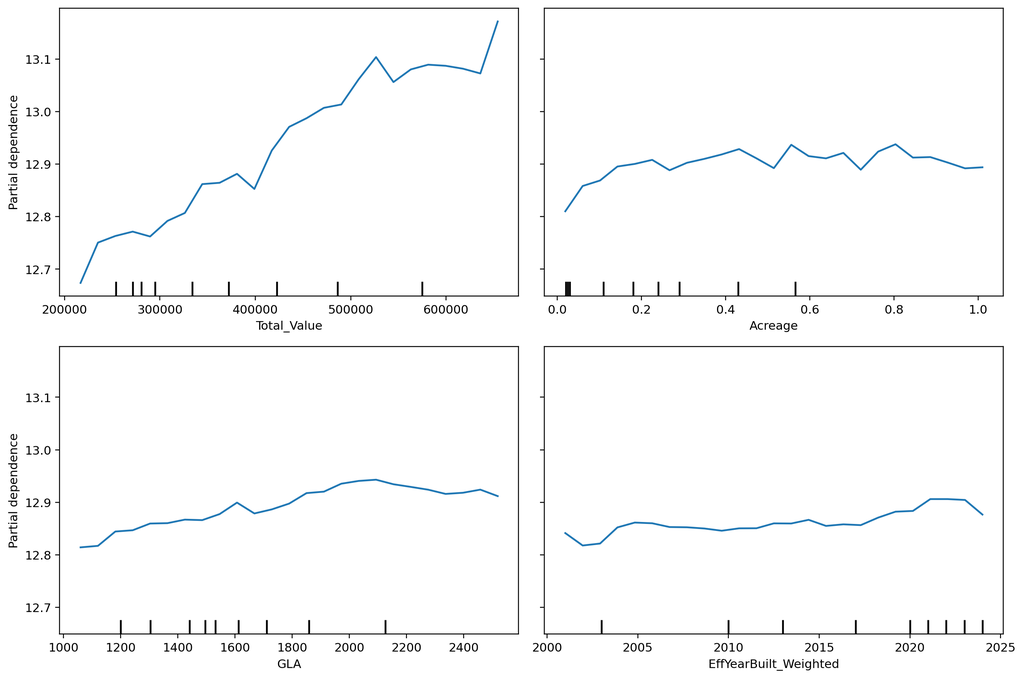

```python
fig, ax = plt.subplots(2, 2, figsize=(12, 8))
PartialDependenceDisplay.from_estimator(
    winner, X_train.sample(min(2000, len(X_train)), random_state=RS),
    top4, ax=ax, grid_resolution=25)
plt.tight_layout(); plt.show()
```